# DSDA 1995

Data Science and Society using R

Lecture 10 | Exploring Data II

## Plan for Today

- Continue to explore data in R

## Covariation

- Describes the behavior between variables
- Is the tendency for the values of two or more variables to vary together in a related way

## Categorical and Continuous Variable

- Let’s say we want to explore the distribution of a continuous variable broken down by a categorical variable
- We could use `geom_freqpoly()`

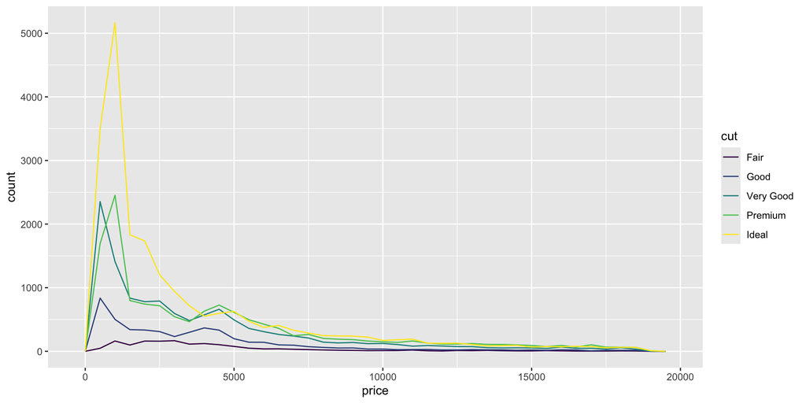

```r
ggplot(data = diamonds, mapping = aes(x = price)) +
  geom_freqpoly(mapping = aes(colour = cut), binwidth = 500)
```

## Categorical and Continuous Variable

- Issues
  - It is based on the raw counts, which means we cannot see variation for categories that have smaller numbers
- Let’s examine the density instead
  - Which is the count standardized so that the area under each frequency polygon is one.

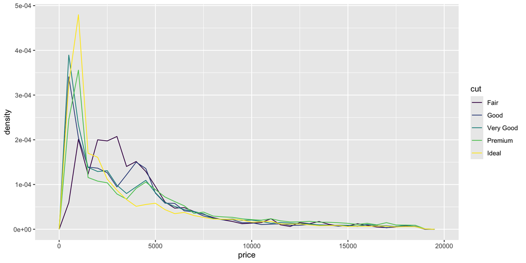

```r
ggplot(data = diamonds, mapping = aes(x = price, y = ..density..)) +
  geom_freqpoly(mapping = aes(colour = cut), binwidth = 500)
```

- What do we notice?
- Do we like this plot? Is it useful?
- Any issues?

## Boxplots

- Lets try an alternative, the `geom_boxplot()`

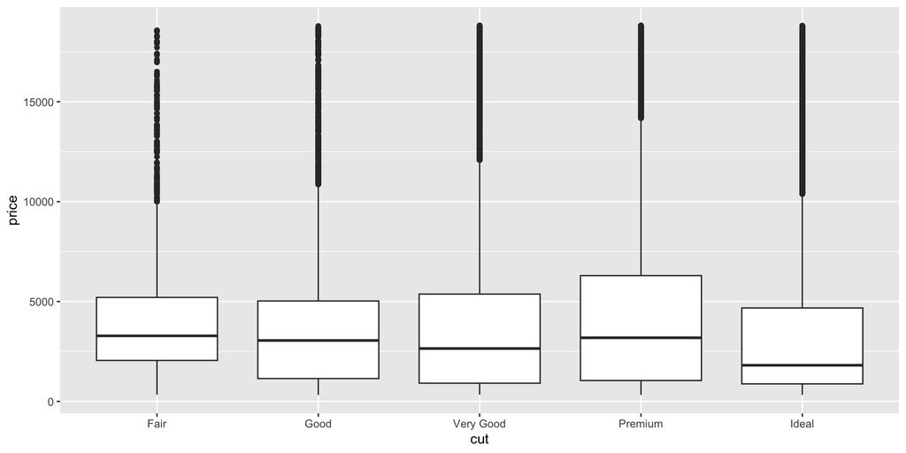

```r
ggplot(data = diamonds, mapping = aes(x = cut, y = price)) +
  geom_boxplot()
```

## Boxplots

- What are box plots?
  - The box provides the IQR (25th to the 75th percentiles)
  - The bar, inside the box, provides us the median (50th percentile)
  - The whiskers extend from each end of the box and go to the farthest non-outlier point in the distribution
  - The points display observations that fall more than 1.5 X IQR from either side of the box
- What do we think about the boxplot?

## Categorical Variable Ordering

- What if our categorical variable does not have an intrinsic order?
- We can utilize the `reorder()` function

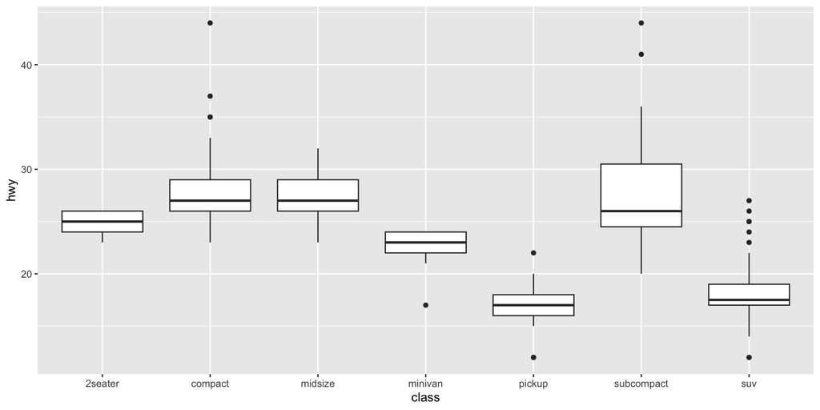

```r
ggplot(data = mpg, mapping = aes(x = class, y = hwy)) +
  geom_boxplot()
```

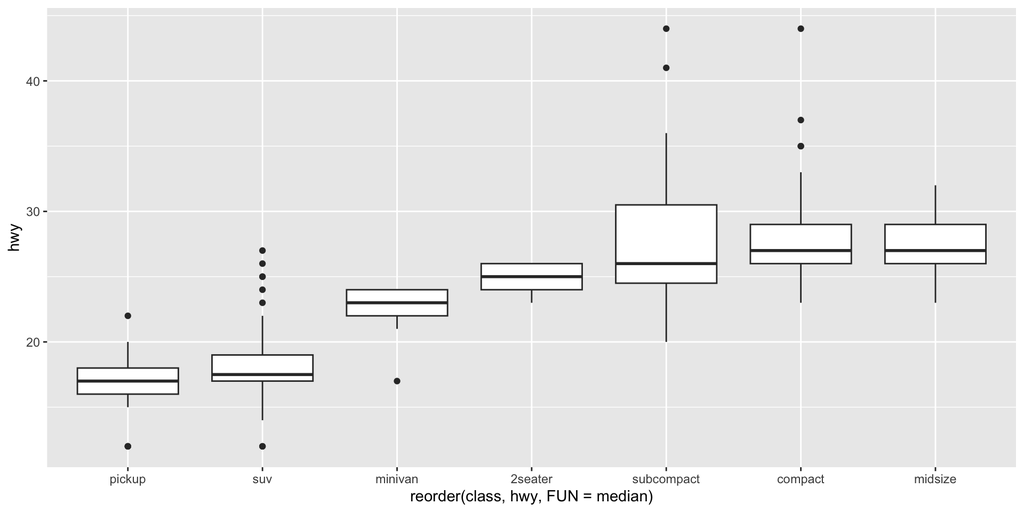

```r
ggplot(data = mpg) +
  geom_boxplot(mapping = aes(x = reorder(class, hwy, FUN = median), y = hwy))
```

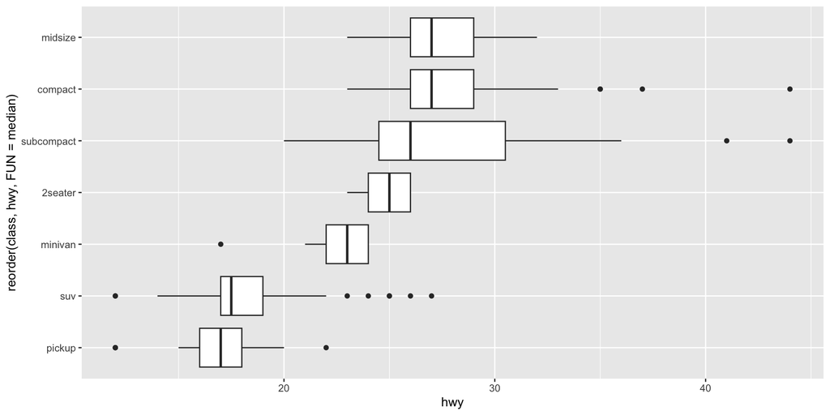

```r
ggplot(data = mpg) +
  geom_boxplot(mapping = aes(x = reorder(class, hwy, FUN = median), y = hwy)) +
  coord_flip()
```

## Two Categorical Variables

- To visualize the covariation between categorical variables, you’ll need to count the number of observations for each combination

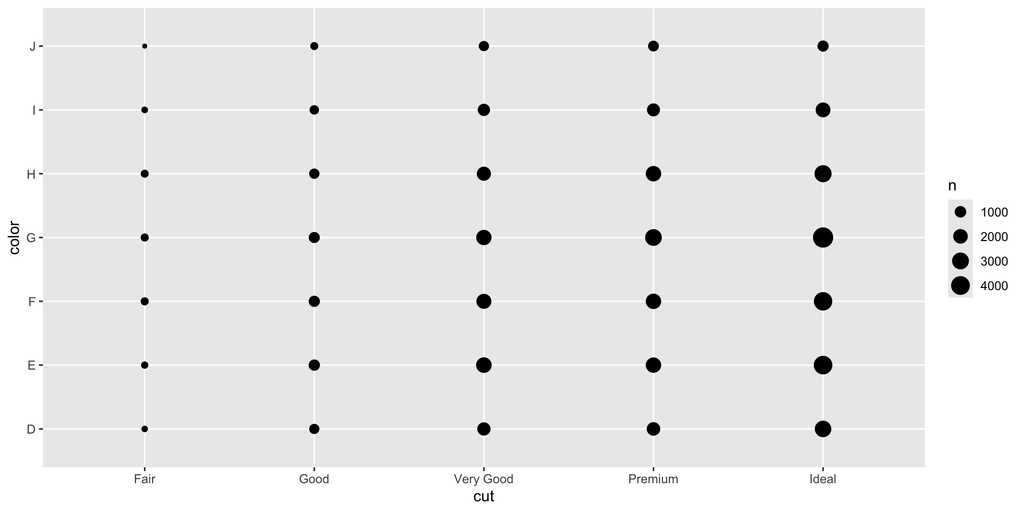

```r
ggplot(data = diamonds) +
  geom_count(mapping = aes(x = cut, y = color))
```

- The size of each circle in the plot displays how many observations occurred at each combination of values

## Two Categorical Variables

- We can also utilize `geom_tile()`

```r
diamonds %>%
  count(color, cut)
```

```
# A tibble: 35 × 3
   color cut           n
   <ord> <ord>     <int>
 1 D     Fair        163
 2 D     Good        662
 3 D     Very Good  1513
 4 D     Premium    1603
 5 D     Ideal      2834
 6 E     Fair        224
 7 E     Good        933
 8 E     Very Good  2400
 9 E     Premium    2337
10 E     Ideal      3903
# ℹ 25 more rows
```

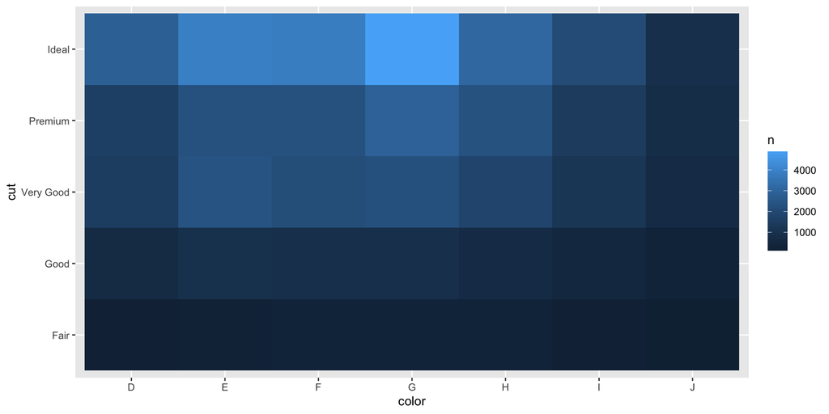

```r
diamonds %>%
  count(color, cut) %>%
  ggplot(mapping = aes(x = color, y = cut)) +
    geom_tile(mapping = aes(fill = n))
```

## Two Continuous Variables

- The scatterplot

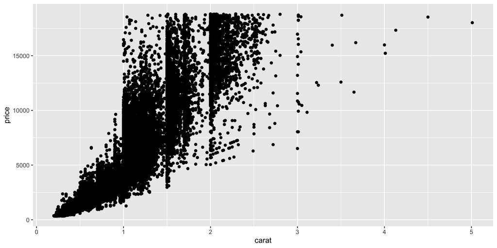

```r
ggplot(data = diamonds) +
  geom_point(mapping = aes(x = carat, y = price))
```

## Two Continuous Variables

- What happens as the number of observations grow in a scatterplot?
- Using the alpha aesthetic to add transparency
- Another option is to use `geom_bin2d()` and `geom_hex()`, which divide the coordinate plane into 2d bins and then use a fill color to display how many points fall into each bin

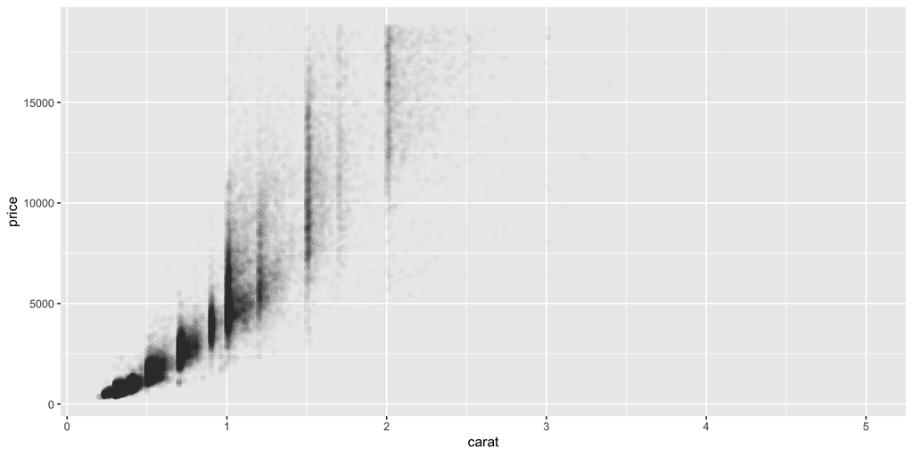

```r
ggplot(data = diamonds) +
  geom_point(mapping = aes(x = carat, y = price), alpha = 1 / 100)
```

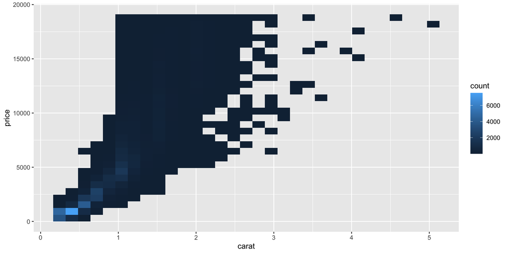

```r
ggplot(data = diamonds) +
  geom_bin2d(mapping = aes(x = carat, y = price))
```

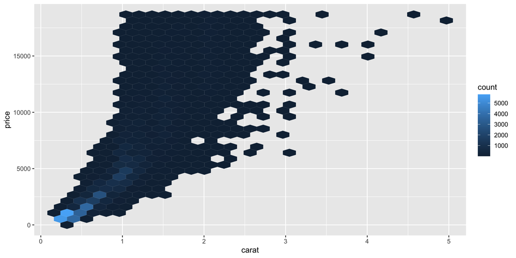

```r
# install.packages("hexbin")
ggplot(data = diamonds) +
  geom_hex(mapping = aes(x = carat, y = price))
```

## Two Continuous Variables

- Additionally, we can bin one of the continuous variables so that it acts like a categorical variable
- `cut_width(x, width)`, as used below, divides x into bins of width width

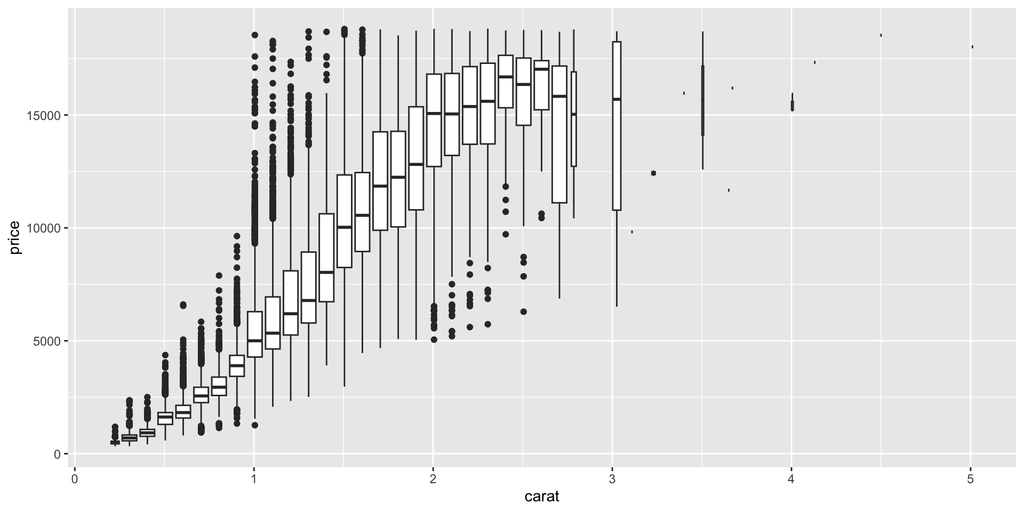

```r
ggplot(data = diamonds, mapping = aes(x = carat, y = price)) +
  geom_boxplot(mapping = aes(group = cut_width(carat, 0.1)))
```

- Another approach is to display approximately the same number of points in each bin using `cut_number()`

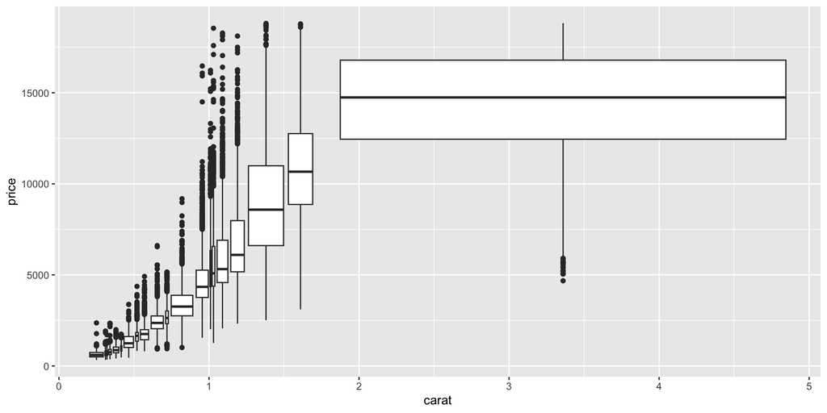

```r
ggplot(data = diamonds, mapping = aes(x = carat, y = price)) +
  geom_boxplot(mapping = aes(group = cut_number(carat, 20)))
```

## Patterns and Models

- Patterns
  - Patterns in your data provide clues about relationships
- If a systematic relationship exists between two variables it will appear as a pattern in the data
  - Could this pattern be due to coincidence (i.e. random chance)?
  - How can you describe the relationship implied by the pattern?
  - How strong is the relationship implied by the pattern?
  - What other variables might affect the relationship?
  - Does the relationship change if you look at individual subgroups of the data?

## Patterns and Models

- A scatterplot of Old Faithful eruption lengths versus the wait time between eruptions shows a pattern

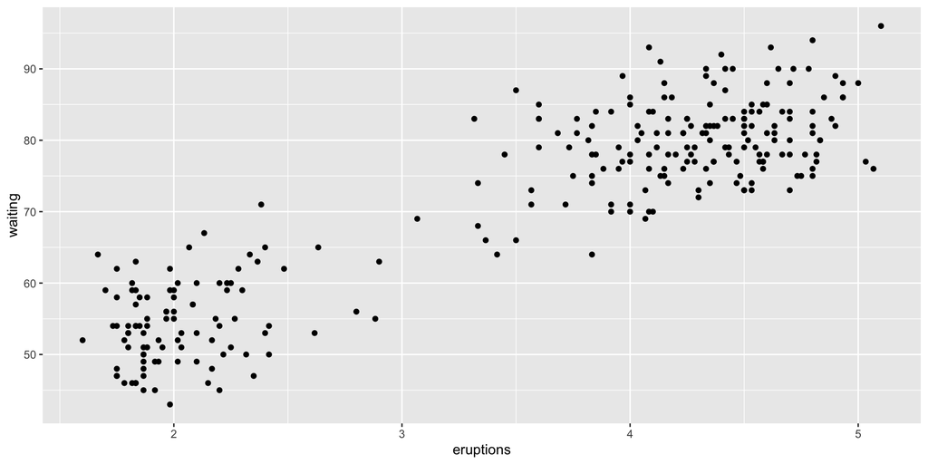

```r
ggplot(data = faithful) +
  geom_point(mapping = aes(x = eruptions, y = waiting))
```

- What do we notice?
- We will discuss models later on in the semester.

## For Next Class

- Review what you learned today
- Do new set of readings:
  - We are going to examine causality
  - R4DS Chapter 5
  - R4DS Chapter 19.1 - 19.2
    - Follow along the exercises with your own computer
- Bring your laptops to class